# Coworking Feasibility Final Paper

## Relative Income

```r
table(TrainCensus2$RelativeIncome, useNA = "ifany")
```

```
##
##             Rather High              Rather Low Somewhere In The Middle
##                      68                      18                      90
##               Very High                Very Low                    <NA>
##                      10                       2                      12
```

```r
table(Census$RelativeIncome, useNA = "ifany")
```

```
##
##             Rather High              Rather Low Somewhere In The Middle
##                    4678                   22055                   16185
##               Very High                Very Low
##                     900                   37475
```

```r
table(MarketCensus$RelativeIncome, useNA = "ifany")
```

```
##
##             Rather High              Rather Low Somewhere In The Middle
##                     376                    1447                    1226
##               Very High                Very Low                    <NA>
##                      56                    2006                       6
```

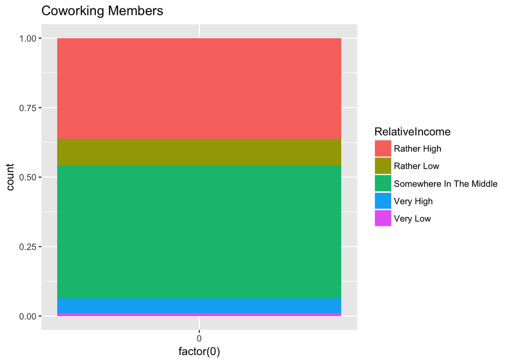

```r
RITrain <- ggplot(subset(TrainCensus2, subset = !is.na(RelativeIncome)), aes(x = factor(0))) +
    geom_bar(aes(fill = RelativeIncome), position = "fill") + ggtitle("Coworking Members")
RITrain
```

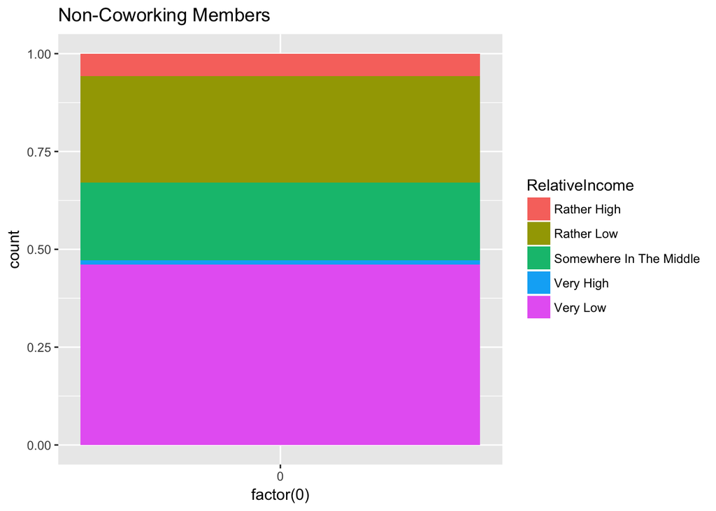

```r
RICensus <- ggplot(subset(Census, subset = !is.na(RelativeIncome)), aes(x = factor(0))) +
    geom_bar(aes(fill = RelativeIncome), position = "fill") + ggtitle("Non-Coworking Members")
RICensus
```

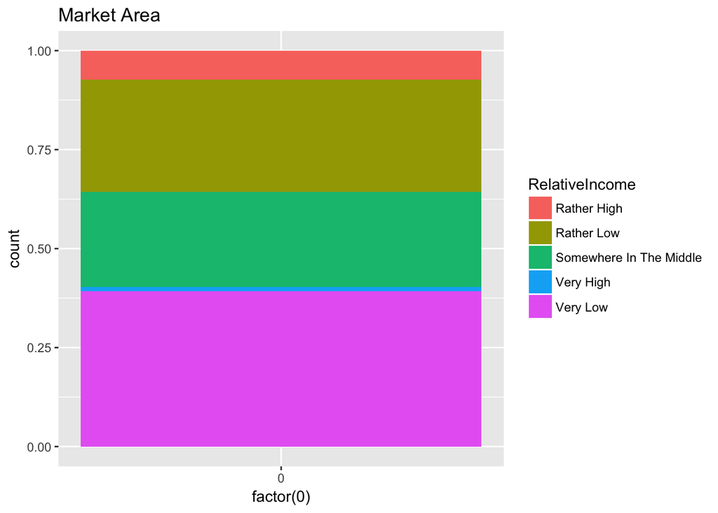

```r
RIMarket <- ggplot(subset(MarketCensus, subset = !is.na(RelativeIncome)), aes(x = factor(0))) +
    geom_bar(aes(fill = RelativeIncome), position = "fill") + ggtitle("Market Area")
RIMarket
```

## Conclusions

Listed below are the observations we’ve made:

- Shockingly, Distance to Home does not play a large role in predicting Coworking Membership, since the 80% of the Coworking Survey and 80% of LA County all live within a 20 minute drive of their Coworking Space.
- Far more Coworkers walked and biked to the Coworking Space compared to the average non-Coworker in Los Angeles County. Only around 1% of people in LA bike, with around 3% walking. However, the same proportions of people took Public Transportation.
- Even fewer people in my targeted market area walk and bike, so I will leave this statistic alone. Seems like this will have a slight negative effect on my Market population.
- There are more 18-29 year olds proportionally going to Coworking Spaces than exist in the LA County population. There are far more 30-39 year olds in the Coworking Spaces as well.
- There are vastly more Entrepreneurs, Freelancers, and Other in Coworking Spaces than in LA County.There are vastly less Employees proportionally in Coworking Spaces.
- The proportion in the Market Area seems to be roughly the same as in LA.
- There are less Designers, IT workers, PR, Researchers, and Writers in LA County than in Coworking Spaces. There are vastly more “Other” folks in LA County than in Coworking Spaces.
- There are proportionally more men in Coworking Spaces than in LA County.
- There are roughly the same proportion of married people, but there are less Unmarried in LA County and more Separated/Divorced/Widowed.
- There are slightly more uninsured in Coworking Spaces.
- There are vastly more people in Coworking Spaces who were previously working in Home Offices than there are people working in Home Offices in LA County.
- There are vastly more people with Bachelors or Masters degrees as their highest educational attainment in Coworking Spaces than in LA County.
- There are more people with Masters Degrees and PhDs within my Market Area, which will have a positive effect on the model.
- There are vastly more Somewhere in the Middle, Rather High, and Very High relative incomes in Coworking Spaces than in LA County.
- The Market Area has more folks Somewhere in the Middle than LA County, which will skew the model positively in our favor.

## Skewing the Training Set

I will need to skew my data set in order to have a model that has more polar opposites between the non-Coworkers and the Coworkers. While this seems biased, it will exaggerate the scores in a more scalable and readable way. I will then compare my Market Area to an area which I know is a strong Coworking market area and one which is not a strong Coworking market area to see in order to eliminate the bias.

The general approach I will take is this: I will delete a random 50% sample from the non-Coworking data set of whichever categorical variable is the highest in the Coworking data. I will also delete 50% of all non-Coworking observations for which the Coworking categories will be statistically significant.

```r
Census2 <- Census

List <- split(Census, Census$CommuteTime)
List$Yes <- sample_frac(List$Yes, size = 0.5)
Census <- rbind(List$Yes, List$No)

Census$Random <- 0
Census$Random[Census$TransportationMode == "Driving" | Census$TransportationMode ==
    "Biking" | Census$TransportationMode == "Walking"] <- 1
List <- split(Census, Census$Random)
List$"1" <- sample_frac(List$"1", size = 0.5)
Census <- rbind(List$"1", List$"0")

Census$Random <- 0
Census$Random[Census$AgeBracket == "18-29" | Census$AgeBracket == "30-39"] <- 1
List <- split(Census, Census$Random)
List$"1" <- sample_frac(List$"1", size = 0.5)
Census <- rbind(List$"1", List$"0")

Census$Random <- 0
Census$Random[Census$ClassOfWorker == "Freelancer" | Census$ClassOfWorker == "Entrepreneur" |
    Census$ClassOfWorker == "Other"] <- 1
List <- split(Census, Census$Random)
List$"1" <- sample_frac(List$"1", size = 0.5)
Census <- rbind(List$"1", List$"0")

Census$Random <- 0
Census$Random[Census$OccupationType == "Design" | Census$OccupationType == "IT" |
    Census$OccupationType == "PR, Marketing, Sales, Advertising" | Census$OccupationType ==
    "Research" | Census$OccupationType == "Writing"] <- 1
List <- split(Census, Census$Random)
List$"1" <- sample_frac(List$"1", size = 0.5)
Census <- rbind(List$"1", List$"0")

Census$Random <- 0
Census$Random[Census$Sex == "Male"] <- 1
List <- split(Census, Census$Random)
List$"1" <- sample_frac(List$"1", size = 0.5)
Census <- rbind(List$"1", List$"0")

Census$Random <- 0
Census$Random[Census$MaritalStatus == "Married" | Census$MaritalStatus == "Not Married"] <- 1
List <- split(Census, Census$Random)
List$"1" <- sample_frac(List$"1", size = 0.5)
Census <- rbind(List$"1", List$"0")

Census$Random <- 0
Census$Random[Census$HealthInsurance == "No Health Insurance"] <- 1
List <- split(Census, Census$Random)
List$"1" <- sample_frac(List$"1", size = 0.5)
Census <- rbind(List$"1", List$"0")

Census$Random <- 0
Census$Random[Census$HomeOffice == "Not Home Office"] <- 1
List <- split(Census, Census$Random)
List$"1" <- sample_frac(List$"1", size = 0.5)
Census <- rbind(List$"1", List$"0")

Census$Random <- 0
Census$Random[Census$EducationLevel == "Bachelor" | Census$EducationLevel == "Master"] <- 1
List <- split(Census, Census$Random)
List$"1" <- sample_frac(List$"1", size = 0.5)
Census <- rbind(List$"1", List$"0")

Census$Random <- 0
Census$Random[Census$RelativeIncome == "Somewhere In The Middle" | Census$RelativeIncome ==
    "Rather High" | Census$RelativeIncome == "Very High"] <- 1
List <- split(Census, Census$Random)
List$"1" <- sample_frac(List$"1", size = 0.5)
Census <- rbind(List$"1", List$"0")

Census <- subset(Census, select = -Random)
TrainCensus <- rbind(TrainCensus2, Census)
write.table(x = TrainCensus, file = "TrainCensus3")
write.table(x = Census2, file = "Census2")
```

```r
TrainCensus <- read.table("TrainCensus3", header = TRUE)
Census2 <- read.table("Census2", header = TRUE)
```

# Applying Linear Regression

```r
CoworkModel <- lm(CoworkMember ~ TransportationMode + AgeBracket + ClassOfWorker +
    OccupationType + Sex + HealthInsurance + HomeOffice + EducationLevel + RelativeIncome,
    data = TrainCensus)

CoworkMember <- predict(CoworkModel, newdata = MarketCensus)
MarketCensus <- cbind(MarketCensus, CoworkMember)

summary(MarketCensus$CoworkMember)
```

```
##    Min. 1st Qu.  Median    Mean 3rd Qu.    Max.    NA's
## -0.1108  0.0131  0.0548  0.0853  0.1221  0.8252    1289
```

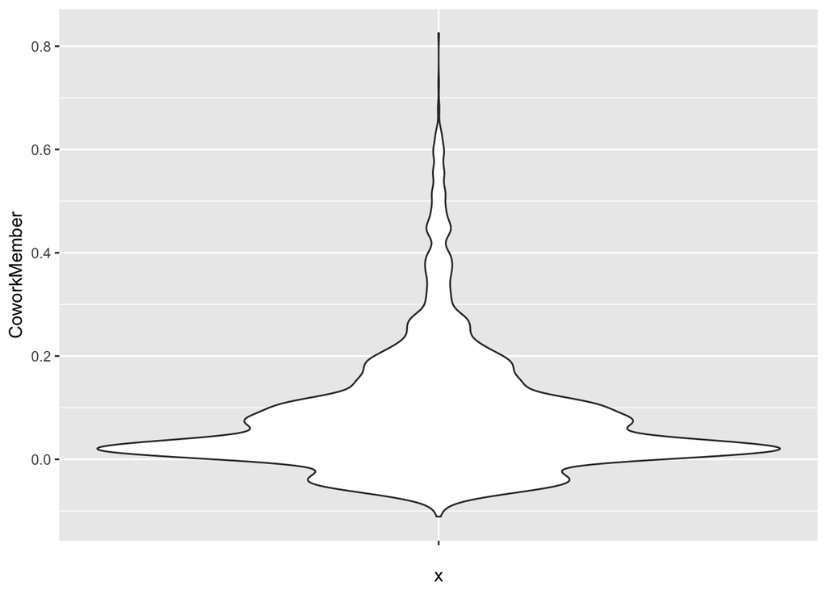

```r
CoworkScores <- ggplot(data = MarketCensus, mapping = aes(x = "", y = CoworkMember)) +
    geom_violin()
CoworkScores
```

It would appear that some natural demarcations to make in this data set are CoworkScores below 0.2, 0.2 - 0.4, and 0.4 and above. We will classify each observation as follows:

- Below 0.2: Not at all likely to be Coworking Member, or “Not Likely”
- 0.2 - 0.4: Could be a Coworking Member, or “Somewhat Likely”
- Above 0.4: Probable to be a Coworking Member, or “Very Likely”

```r
MarketCensus <- MarketCensus[!is.na(MarketCensus$CoworkMember), ]
MarketCensus$CoworkLikely[MarketCensus$CoworkMember < 0.2] <- "Not Likely"
MarketCensus$CoworkLikely[MarketCensus$CoworkMember >= 0.2 & MarketCensus$CoworkMember <
    0.4] <- "Somewhat Likely"
MarketCensus$CoworkLikely[MarketCensus$CoworkMember >= 0.4] <- "Very Likely"

table(MarketCensus$CoworkLikely)
```

```
##
##      Not Likely Somewhat Likely     Very Likely
##            3338             361             129
```

## Comparing to other Market Areas

I will compare the Market Area in question to a few Market Areas in the Los Angeles region that we can say are good and bad areas for Coworking Spaces.

The first one we will use is the PUMA area conatining Santa Monica, which is considered a hub of the region known as “Silicon Beach”. This area contains a large amount of residents in the technology industry, so the “IT” count will be high in “Occupation Type”. The income should be relatively high, there should be a large number of folks with bachelors and masters degrees, and everyone will live within a close proximity to a Coworking Space.

The second area I will use to test is the Compton/Rancho Dominguez area, which is very far from the nearest Coworking Space and has a relatively low income level.

```r
TestAreaSM <- subset(Census2, subset = (PUMA == 3728 | PUMA == 3751 | PUMA == 3752),
    select = -CoworkMember)
TestAreaSM$CommuteTime <- "Yes"
TestAreaCRD <- subset(Census2, subset = (PUMA == 3757 | PUMA == 3756 | PUMA == 3758),
    select = -CoworkMember)
TestAreaCRD$CommuteTime <- "No"
TestAreaSM$TransportationMode[is.na(TestAreaSM$TransportationMode)] <- "Driving"
TestAreaCRD$TransportationMode[is.na(TestAreaCRD$TransportationMode)] <- "Driving"
CoworkMember <- predict(CoworkModel, newdata = TestAreaSM)
TestAreaSM <- cbind(TestAreaSM, CoworkMember)
CoworkMember <- predict(CoworkModel, newdata = TestAreaCRD)
TestAreaCRD <- cbind(TestAreaCRD, CoworkMember)

TestAreaSM <- TestAreaSM[!is.na(TestAreaSM$CoworkMember), ]
TestAreaSM$CoworkLikely[TestAreaSM$CoworkMember < 0.2] <- "Not Likely"
TestAreaSM$CoworkLikely[TestAreaSM$CoworkMember >= 0.2 & TestAreaSM$CoworkMember <
    0.4] <- "Somewhat Likely"
TestAreaSM$CoworkLikely[TestAreaSM$CoworkMember >= 0.4] <- "Very Likely"

table(TestAreaSM$CoworkLikely)
```

```
##
##      Not Likely Somewhat Likely     Very Likely
##            1948             183              89
```

```r
TestAreaCRD <- TestAreaCRD[!is.na(TestAreaCRD$CoworkMember), ]
TestAreaCRD$CoworkLikely[TestAreaCRD$CoworkMember < 0.2] <- "Not Likely"
TestAreaCRD$CoworkLikely[TestAreaCRD$CoworkMember >= 0.2 & TestAreaCRD$CoworkMember <
    0.4] <- "Somewhat Likely"
TestAreaCRD$CoworkLikely[TestAreaCRD$CoworkMember >= 0.4] <- "Very Likely"

table(TestAreaCRD$CoworkLikely)
```

```
##
##      Not Likely Somewhat Likely     Very Likely
##            2142             111              31
```

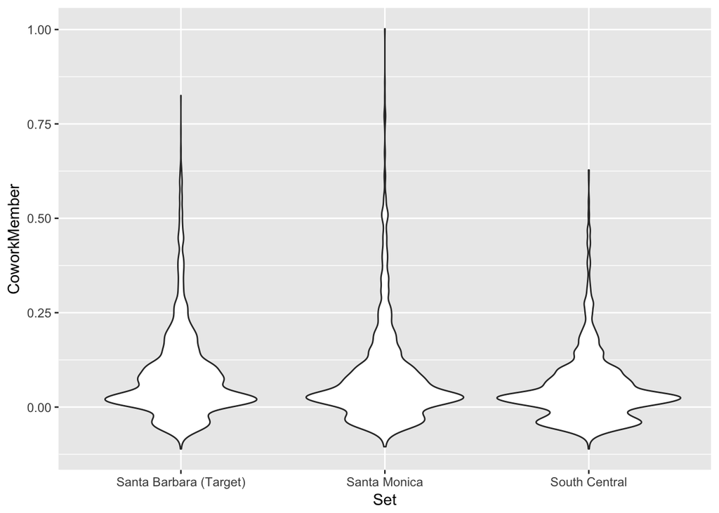

```r
TSM1 <- sample_n(TestAreaSM, size = 1544, replace = FALSE)
TSM2 <- sample_n(TestAreaCRD, size = 1608, replace = FALSE)

MarketCensus$Set <- "Santa Barbara (Target)"
TestAreaSM$Set <- "Santa Monica"
TestAreaCRD$Set <- "South Central"
TestAreaSM <- subset(TestAreaSM, select = -PUMA)
TestAreaCRD <- subset(TestAreaCRD, select = -PUMA)
TestAreaSM$Tract <- 0
TestAreaCRD$Tract <- 0
TSM1 <- sample_n(TestAreaSM, size = 1544, replace = FALSE)
TSM2 <- sample_n(TestAreaCRD, size = 1608, replace = FALSE)
TestAreaSM <- rbind(TestAreaSM, TSM1)
TestAreaCRD <- rbind(TestAreaCRD, TSM2)
MarketCensusPlot <- rbind(MarketCensus, TestAreaSM, TestAreaCRD)
CoworkCompare <- ggplot(data = MarketCensusPlot, mapping = aes(x = Set, y = CoworkMember)) +
    geom_violin()
CoworkCompare
```

Now if we look at the tables of the metrics broken down into likelihood we see the following:

```r
table(MarketCensus$CoworkLikely)
```

```
##
##      Not Likely Somewhat Likely     Very Likely
##            3338             361             129
```

```r
table(TestAreaSM$CoworkLikely)
```

```
##
##      Not Likely Somewhat Likely     Very Likely
##            3297             320             147
```

```r
table(TestAreaCRD$CoworkLikely)
```

```
##
##      Not Likely Somewhat Likely     Very Likely
##            3649             191              52
```

```r
summary(MarketCensus$CoworkMember)
```

```
##     Min.  1st Qu.   Median     Mean  3rd Qu.     Max.
## -0.11083  0.01314  0.05485  0.08525  0.12213  0.82525
```

```r
summary(TestAreaSM$CoworkMember)
```

```
##      Min.   1st Qu.    Median      Mean   3rd Qu.      Max.
## -0.104938  0.007243  0.037923  0.079893  0.107413  1.001853
```

```r
summary(TestAreaCRD$CoworkMember)
```

```
##      Min.   1st Qu.    Median      Mean   3rd Qu.      Max.
## -0.110832 -0.008574  0.030344  0.049867  0.080250  0.627973
```

# Conclusion

We see that the Santa Barbara Market Area actually has more people than Santa Monica that are categorized as “Somewhat Likely” which is a really good indication of strong customer potentiality in that region.

However, Santa Monica has a much higher max potentiality for the upper echelon customers.

Clearly Santa Barbara Market Areas have a much higher customer potentiality than the Compton/Rancho Dominguez area which has been classified as a poor customer potentiality area.

I believe that according to this model, Our proposed location would be a good fit for a Coworking Space. Since the maximum potentiality is lower than in a known strong market area, however, I believe the scope of the project should be considered more of a boutique operation instead of a full fledged space.

## What’s Next?

Now that we have our answer, what’s next to be done with the data? The next very useful operation to perform would be to create a readout of what Census Tracts have the strongest customer potentiality. This should be accompanied by a heat-map diagram split up by Census Tract.

Next, there should be an analysis of the impact of local competition. Are there competitors nearby that suck up Market Share? How close are they to our space? We should re-run an analysis of CommuteTime, this time incorporating other Santa Barbara area Coworking Spaces into our data set using my partnership with Coworker.com.

# The Recommendation for the project at this point: Proceed with the Coworking Space!